# Week 2 - Intro to R, Part 2

C.A. Kiahtipes

8/22/2023

## Week 2: Introduction to R, Part II

At the end of the week 1 exercise, I introduced a first custom function. These are handy and we will keep using them.

```r
draw_grid = function(x, y, line_type = 3){ #Here I am naming the function and setting its arguments, R sees "draw_grid" and looks for input (x, y).

  for(i in 1:length(x)){ #For every integer up to the length of x

      lines(c(min(x),max(x)),c(y[i],y[i]), lty = line_type) #Draw a line along the x axis
      lines(c(x[i],x[i]),c(min(y),max(y)), lty = line_type) #Draw a line along the y axis

  } #Closing loop iterating through the vector.

} #Closing out function definition.
```

Last week we worked with vectors and lists, eventually making it possible to make some basic plots.

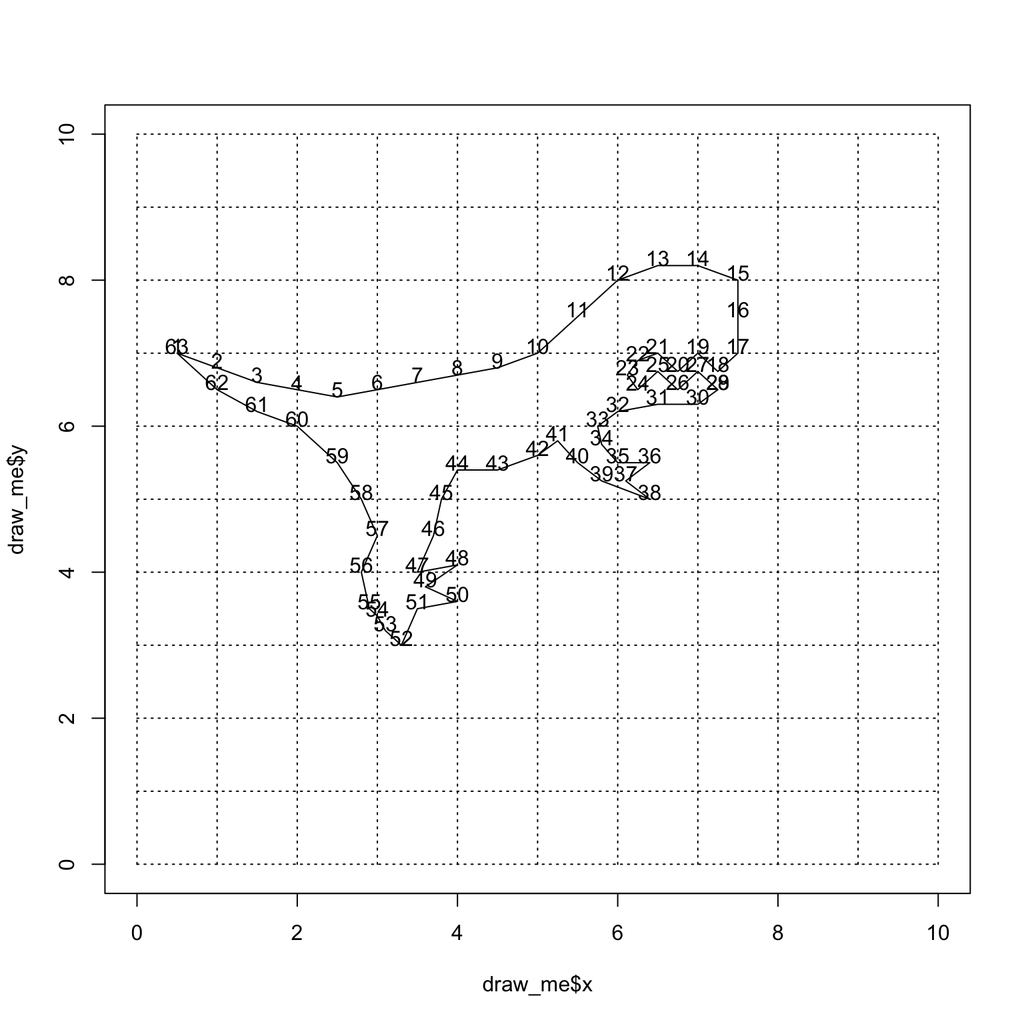

```r
draw_me = list(x = c(0.5, 1, 1.5, 2, 2.5, 3, 3.5, 4, 4.5, 5, 5.5, 6, 6.5, 7, 7.5, 7.5, 7.5, 7.25, 7, 6.75, #We open the list() function here...
       6.5, 6.25, 6.12, 6.25, 6.5, 6.75, 7, 7.25, 7.25, 7, 6.5, 6, 5.75, 5.8, 6, 6.4, 6.1, 6.4, 5.8, 5.5,
       5.25, 5, 4.5, 4, 3.8, 3.7, 3.5, 4, 3.6, 4, 3.5, 3.3, 3.1, 3, 2.9, 2.8, 3, 2.8, 2.5, 2,
       1.5, 1, 0.5), #Note that we end with a comma here because we have to enter the y object still...

              y = c(7, 6.8, 6.6, 6.5, 6.4, 6.5, 6.6, 6.7, 6.8, 7, 7.5, 8, 8.2, 8.2, 8, 7.5, 7, 6.75, 7, 6.75,
       7, 6.9, 6.7, 6.5, 6.75, 6.5, 6.75, 6.5, 6.5, 6.3, 6.3, 6.2, 6, 5.75, 5.5, 5.5, 5.25, 5, 5.25, 5.5,
       5.8, 5.6, 5.4, 5.4, 5, 4.5, 4, 4.1, 3.8, 3.6, 3.5, 3, 3.2, 3.4, 3.5, 4, 4.5, 5, 5.5, 6,
       6.2, 6.5, 7)) #Here we add the last parentheses to close out the list function call above.


plot(draw_me,
     type = "l",
     xlim = c(0,10),
     ylim = c(0,10))

text(draw_me$x, draw_me$y+0.1, c(1:length(draw_me$y)))

draw_grid(0:10, 0:10) #Calling a custom function here to draw a grid in the background.
```

Today, I’d like to expand on that and start working with table/matrix data organizations.

### Working in R: Matrix Objects

Matrices are tables of data, which by definition has two dimensions. This adds one more layer of complexity to our vector objects and it is worth discussing how we create and interact with these objects. In most research settings, we primarily interact with matrices. Let’s use the base function matrix() to create a two-dimensional data set.

```r
my_matrix = matrix(data = c(1:10, 11:20, 111:120)) #We are using the arguments "data = ".

is.matrix(my_matrix) #We can interrogate the object and see if it is a matrix.
```

```
## [1] TRUE
```

Now, at this point we’ve made a matrix object and determined that it is indeed a matrix. Let’s call the object and see our matrix looks like.

```r
my_matrix
```

```
##       [,1]
##  [1,]    1
##  [2,]    2
##  [3,]    3
##  [4,]    4
##  [5,]    5
##  [6,]    6
##  [7,]    7
##  [8,]    8
##  [9,]    9
## [10,]   10
## [11,]   11
## [12,]   12
## [13,]   13
## [14,]   14
```

[output cut: 16 more lines]

Because we used matrix() and fed it 30 integers, but *did not* define the number of rows or columns, R made a matrix with one column. Let’s look at the arguments available in matrix and then make a more sensible matrix.

```r
help(matrix)
```

The help page shows us that there are five arguments we can give to matrix(), including the number of rows and columns. This will let us make a more useful matrix. We will also introduce objects to give names to our rows and columns.

```r
my_cols = c("Species 1", "Species 2", "Species 3")
my_rows = c("Site 1", "Site 2", "Site 3", "Site 4", "Site 5", "Site 6", "Site 7", "Site 8", "Site 9", "Site 10")

my_names = list(my_rows, my_cols) #We're making a list here with the two vector objects above.

my_matrix = matrix(data = c(1:10, 11:20, 111:120), ncol = 3, dimnames = my_names) #Note we don't have to specify row number.
```

Just like vectors, we can make empty matrices that we can populate with data later. All we need to do is specify the number of rows and columns.

### Working in R: Navigating Matrix Objects

We interact with matrices in the same way we do vectors, with one minor difference. We use the object’s name plus the bracket ([]) symbol, but we need to specify the row and column position, which is done by separating them with a comma ([row, column]). We can see this in action below.

```r
my_matrix[, 1] = 1:10 #We're taking the columns in order here
my_matrix[, 2] = 11:20
my_matrix[, 3] = 111:120

#An alternative method using column names.

my_matrix[, "Species 1"] = 1:10
my_matrix[, "Species 2"] = 11:20
my_matrix[, "Species 3"] = 111:120
```

The brackets also allow us to call specific sections of the data within any matrix.

```r
my_matrix[, 1]
```

```
##  Site 1  Site 2  Site 3  Site 4  Site 5  Site 6  Site 7  Site 8  Site 9 Site 10
##       1       2       3       4       5       6       7       8       9      10
```

```r
my_matrix[1, ]
```

```
## Species 1 Species 2 Species 3
##         1        11       111
```

```r
my_matrix[2, 2:3]
```

```
## Species 2 Species 3
##        12       112
```

```r
my_matrix[c(2, 4, 8), 3] #When can choose non-consecutive rows here with concatenate.
```

```
## Site 2 Site 4 Site 8
##    112    114    118
```

We can select segments of the matrix based on values in other columns of the dataset. The code below uses the values for Species 2 to select the rows of Species 1 to be displayed.

```r
my_matrix[my_matrix[, "Species 2"] > 15, "Species 1"]
```

```
##  Site 6  Site 7  Site 8  Site 9 Site 10
##       6       7       8       9      10
```

Matrix objects, like vectors, are composed of a uniform type of data - either numeric, character, or logical. If we force matrix() to take multiple kinds of input, it will default to character.

```r
my_matrix <- matrix(data = c(9, "A", TRUE, "words", 11, 12, 111, 134, 9, FALSE),
       ncol = 5)

is.character(my_matrix)
```

```
## [1] TRUE
```

```r
my_matrix
```

```
##      [,1] [,2]    [,3] [,4]  [,5]
## [1,] "9"  "TRUE"  "11" "111" "9"
## [2,] "A"  "words" "12" "134" "FALSE"
```

We can use a matrix of logical or character variables to subset our data. Here, we use a logical statement to create a new logical object (my_logicl) that we can use to retrieve a subset of my_matrix.

```r
my_matrix <- matrix(data = c(1:10, 11:20, 111:120), ncol = 3, dimnames = my_names)

my_logicl <- my_matrix > 10

is.logical(my_logicl)
```

```
## [1] TRUE
```

```r
my_matrix[my_logicl]
```

```
##  [1]  11  12  13  14  15  16  17  18  19  20 111 112 113 114 115 116 117 118 119
## [20] 120
```

### Working in R: Data Frames

R has a special class of objects that allows us to combine multiple data types and is one of the more useful object classes in R: data frames. These can be defined by calling the data frame function (“data.frame()”) or you can coerce a given object into this class with “as.data.frame()”. R will read some data as a data.frame by default as well, which we explore below.

For now, let’s construct a data frame object with some logical arguments and categorical variables.

```r
my_df <- data.frame(taxa_1 = c(1:10), #We're defining objects as a part of the arguments going into data.frame()
                    taxa_2 = c(11:20),
                    taxa_3 = c(21:30),
                    burned = c(TRUE, TRUE, TRUE, TRUE, FALSE, FALSE, FALSE, FALSE, TRUE, FALSE),
                    class1 = c("Oak Scrub", "Oak Scrub", "Oak Scrub", #Don't be afraid to use <shift+enter> to break down long arguments.
                               "Pine Woodland", "Pine Woodland",
                               "Estuarine", "Estuarine",
                               "Savanna", "Savanna", "Savanna"),
                    row.names = c("Site 1", "Site 2", "Site 3", "Site 4", "Site 5", "Site 6", "Site 7", "Site 8", "Site 9", "Site 10"))

my_df
```

```
##         taxa_1 taxa_2 taxa_3 burned        class1
## Site 1       1     11     21   TRUE     Oak Scrub
## Site 2       2     12     22   TRUE     Oak Scrub
## Site 3       3     13     23   TRUE     Oak Scrub
## Site 4       4     14     24   TRUE Pine Woodland
## Site 5       5     15     25  FALSE Pine Woodland
## Site 6       6     16     26  FALSE     Estuarine
## Site 7       7     17     27  FALSE     Estuarine
## Site 8       8     18     28  FALSE       Savanna
## Site 9       9     19     29   TRUE       Savanna
## Site 10     10     20     30  FALSE       Savanna
```

We can retrieve information a lot easier from the data.frame object. The “$” operator lets us pull individual columns from the data.frame. This also shows us that by default, R views the columns as the variables and the rows as the subjects. This is important when it comes to plotting and conducting more sophisticated analyses.

```r
my_df$burned
```

```
##  [1]  TRUE  TRUE  TRUE  TRUE FALSE FALSE FALSE FALSE  TRUE FALSE
```

```r
my_df[my_df$burned == TRUE, ]
```

```
##        taxa_1 taxa_2 taxa_3 burned        class1
## Site 1      1     11     21   TRUE     Oak Scrub
## Site 2      2     12     22   TRUE     Oak Scrub
## Site 3      3     13     23   TRUE     Oak Scrub
## Site 4      4     14     24   TRUE Pine Woodland
## Site 9      9     19     29   TRUE       Savanna
```

```r
my_df[my_df$class1 == "Savanna", ]
```

```
##         taxa_1 taxa_2 taxa_3 burned  class1
## Site 8       8     18     28  FALSE Savanna
## Site 9       9     19     29   TRUE Savanna
## Site 10     10     20     30  FALSE Savanna
```

We can even combine our subsetting calls. We will use both the “and” (“&”) and the “or” (“|”) operators to call different subsets of the data frame. This is also possible with a matrix, but the calls can be more cumbersome.

```r
my_df[my_df$burned == FALSE & my_df$class1 == "Savanna", ]
```

```
##         taxa_1 taxa_2 taxa_3 burned  class1
## Site 8       8     18     28  FALSE Savanna
## Site 10     10     20     30  FALSE Savanna
```

```r
my_df[my_df$burned == FALSE | my_df$class1 == "Savanna", ]
```

```
##         taxa_1 taxa_2 taxa_3 burned        class1
## Site 5       5     15     25  FALSE Pine Woodland
## Site 6       6     16     26  FALSE     Estuarine
## Site 7       7     17     27  FALSE     Estuarine
## Site 8       8     18     28  FALSE       Savanna
## Site 9       9     19     29   TRUE       Savanna
## Site 10     10     20     30  FALSE       Savanna
```

Data frames store the objects as well as their classes. You can check this using the same queries we used for vectors, supplying the column instead. Indeed, R recognizes these columns as individual vectors.

```r
is.numeric(my_df$taxa_1)
```

```
## [1] TRUE
```

```r
is.character(my_df$class1)
```

```
## [1] TRUE
```

```r
is.vector(my_df$taxa_1)
```

```
## [1] TRUE
```

We are using row and column names, which allows us to call rows and columns quickly. R has functions row.names() and colnames() which will fetch or assign row names to a matrix or data frame object. Assigning row or column names is done by supplying the “=” operator as well as a suitable vector of unique row names or any column names.

```r
row.names(my_df)
```

```
##  [1] "Site 1"  "Site 2"  "Site 3"  "Site 4"  "Site 5"  "Site 6"  "Site 7"
##  [8] "Site 8"  "Site 9"  "Site 10"
```

```r
colnames(my_df)
```

```
## [1] "taxa_1" "taxa_2" "taxa_3" "burned" "class1"
```

```r
row.names(my_df) = c("S1", "S2", "S3", "S4", "S5", "S6", "S7", "S8", "S9", "S10")

colnames(my_df) = c("Cercocarpus", "Typha", "Poaceae", "Burned", "Class")

my_df['S5', ]
```

```
##    Cercocarpus Typha Poaceae Burned         Class
## S5           5    15      25  FALSE Pine Woodland
```

```r
my_df[c('S5', 'S8', 'S10'), ] #We can call all of the rows for non-consecutive names.
```

```
##     Cercocarpus Typha Poaceae Burned         Class
## S5            5    15      25  FALSE Pine Woodland
## S8            8    18      28  FALSE       Savanna
## S10          10    20      30  FALSE       Savanna
```

```r
my_df[c('S5', 'S8', 'S10'), 'Class'] #We can call specific rows for non-consecutive names.
```

```
## [1] "Pine Woodland" "Savanna"       "Savanna"
```

We often want to check our data to make sure that it has been read correctly or as a part of troubleshooting. We can use R functions head() and tail() to look at the bottom and the top of our data frame quickly. This will be more important later when we start working with much larger data sets.

```r
head(my_df)
```

```
##    Cercocarpus Typha Poaceae Burned         Class
## S1           1    11      21   TRUE     Oak Scrub
## S2           2    12      22   TRUE     Oak Scrub
## S3           3    13      23   TRUE     Oak Scrub
## S4           4    14      24   TRUE Pine Woodland
## S5           5    15      25  FALSE Pine Woodland
## S6           6    16      26  FALSE     Estuarine
```

```r
tail(my_df)
```

```
##     Cercocarpus Typha Poaceae Burned         Class
## S5            5    15      25  FALSE Pine Woodland
## S6            6    16      26  FALSE     Estuarine
## S7            7    17      27  FALSE     Estuarine
## S8            8    18      28  FALSE       Savanna
## S9            9    19      29   TRUE       Savanna
## S10          10    20      30  FALSE       Savanna
```

### Working in R: Reading Data into R

In most circumstances, we will not be creating our data tables in R. It is more convenient to enter data into Microsoft Excel than it is to do so in R. Software packages that interact with spectrometers or other tools for measurement often give output in the form of a .csv or .txt file, which are readily opened with Excel and edited, checked for errors, and saved again as an .xlsx file. R can read all of these data formats, so long as you tell it what to expect.

Text-based data storage requires a method for identifying columns, rows, and lines. Spaces that look blank on the screen still encode important information. We will see a few of these below.

One of the most common storage formats is .csv (comma separated values). This week’s lab includes a folder full of data that you can read into R. It must be named “data” and must be in your working directory. R will read it as a data frame object.

```r
my_data = read.csv(file = "data/Fake_core.csv",
                   header = TRUE)

class(my_data)
```

```
## [1] "data.frame"
```

Another common data storage format is tab-delimited text files (.txt). R has a specific funciton to read it.

```r
my_data = read.delim(file = "data/Fake_core_plus.txt",
                     header = TRUE)

class(my_data)
```

```
## [1] "data.frame"
```

```r
my_data = read.table(file = "data/Fake_core_plus.txt",
                     header = TRUE,
                     sep = "\t", #Here we tell the function what kind of code separates column entries
                     row.names = "depth") #We can also specify row names when reading.

class(my_data)
```

```
## [1] "data.frame"
```

```r
my_data = read.table(file = "data/Fake_core.csv",
                     header = TRUE,
                     sep = ",",
                     row.names = "depth")

head(my_data)
```

```
##     Cyperaceae.undiff. Typha Poaceae Alchornea Macaranga Celtis Blighia
## -2                  10     3      50        10         3     28      16
## -4                  11     3      46        25        16     33      14
## -6                   6     3      35        35        26     16      16
## -8                  19     3      42         3        43     17      19
## -10                  9     2      57        38        12     24      18
## -12                 15     3      69        18        34     24      19
##     Sapotaceae.undiff. Guibourtia.demeusei
## -2                  25                  25
## -4                  25                  28
## -6                  13                  26
## -8                   9                  24
## -10                 22                  26
## -12                 21                  23
```

Above, I’ve used a more verbose code that shows all of the details. You can simplify the arguments within R as it expects them in a certain order. This allows you to code with a bit more efficiency. The row.names argument needs to be specified.

```r
my_data = read.csv("data/Fake_core.csv", TRUE, row.names = "depth")
```

We can read xlsx file types directly, but not in base R. My preference is to use .xlsx files for data entry in the lab or for translating observations from my notebook or a device to my computer. When it is time for data analysis, I create .csv files that feed into my R workflow.

One of R’s advantages is that you can use packages to install libraries of functions produced by other users. Some of these can be used to read .xlsx files with relative ease. Below, I’m using “::” operators to peek inside of one of the packages on my machine and use one of its functions - “read_xlsx()”. This may not work on your machine, since you need to have the readxl package installed.

```r
readxl::read_xlsx("data/Fake_core_plus.xlsx") #I'm hashing this out because it will require dependencies that might not yet be installed on everyone's machines.
```

```
## # A tibble: 100 × 11
##    depth `Cyperaceae undiff.` Typha Poaceae Alchornea Macaranga Celtis Blighia
##    <dbl>                <dbl> <dbl>   <dbl>     <dbl>     <dbl>  <dbl>   <dbl>
##  1    -2                   10     3      50        10         3     28      16
##  2    -4                   11     3      46        25        16     33      14
##  3    -6                    6     3      35        35        26     16      16
##  4    -8                   19     3      42         3        43     17      19
##  5   -10                    9     2      57        38        12     24      18
##  6   -12                   15     3      69        18        34     24      19
##  7   -14                   12     2      69        32        10     13      13
##  8   -16                   14     4      53         4         1     25      15
##  9   -18                    9     4      49        10         8     22      15
## 10   -20                   21     3      38        29        16     19      12
## # ℹ 90 more rows
## # ℹ 3 more variables: `Sapotaceae undiff.` <dbl>, `Guibourtia demeusei` <dbl>,
## #   stratum <chr>
```

### Working in R: Useful functions in base R

R gives us a lot of tools with which we can evaluate and visualize our data. These are common and useful functions that are worth committing to memory as much as possible. We can use some functions to interrogate objects and learn about their size and contents.

- class()
- length()
- nrow()
- ncol()
- max()
- min()

Here’s some useful functions with logical outputs.

- is.vector()
- is.data.frame()
- is.matrix()
- is.character()
- is.numeric()

```r
my_data = read.csv("data/Fake_core.csv", TRUE, row.names = "depth")

my_int = 1:10

class(my_data)
```

```
## [1] "data.frame"
```

```r
class(my_int)
```

```
## [1] "integer"
```

```r
length(my_int)
```

```
## [1] 10
```

```r
length(my_data)
```

```
## [1] 9
```

```r
ncol(my_data)
```

```
## [1] 9
```

```r
nrow(my_data)
```

```
## [1] 100
```

```r
max(my_int)
```

```
## [1] 10
```

```r
max(my_data)
```

```
## [1] 115
```

Useful functions for gathering insights from our data.

- sum()
- mean()
- median()
- mode()

Useful functions with basic plots

- hist()
- barplot()
- boxplot()

## Working in R: Exploring The plot() Function

Now that I have scared everyone, let’s do something fun. We’re going to make our own vectors, put them in a list, and use them to draw pictures with the plot function. Let’s get to know our options by exploring the arguments for plot(). We can submit any object as the input for an argument in plot, so long as the data to be plotted is divisible the object being submitted as an argument.

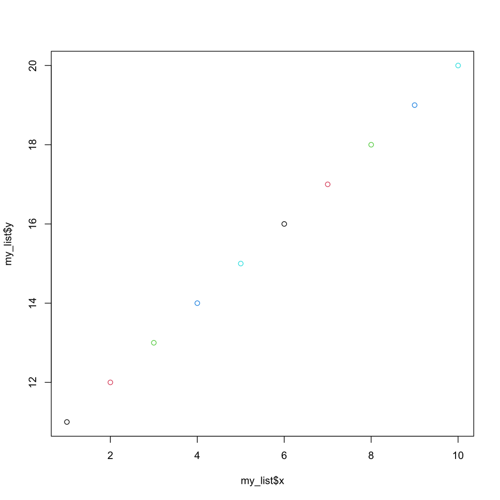

```r
my_list = list(x = 1:10, y = 11:20, col = c(1:5)) #Note here we're only using a list of five integers for colors.

plot(my_list, col = my_list$col)
```

```r
#What's wrong with this plot?
```

Let’s get to know some of the other arguments in plot() that will be useful to know. More important than knowing every possible argument, we’re trying to learn how to use vectors of data to create visualizations. This is a key step toward communicating reliable and replicate-able results. Thus, we’re going to make a grid of data points and then vary a few parameters across the entire grid. Then, we can examine the results and use this as a cheat sheet for future coding. We will need to use some base R functions to construct our vectors.

Below are three methods for making our grid. We might evaluate which is best by the number of lines of code it takes, the general portability of the code (does it apply in any circumstance?), and how challenging it is to come up with. I introduce the apply() family of functions below because they are initially scary, but very useful. By combining them with custom functions, you can achieve a lot with a little.

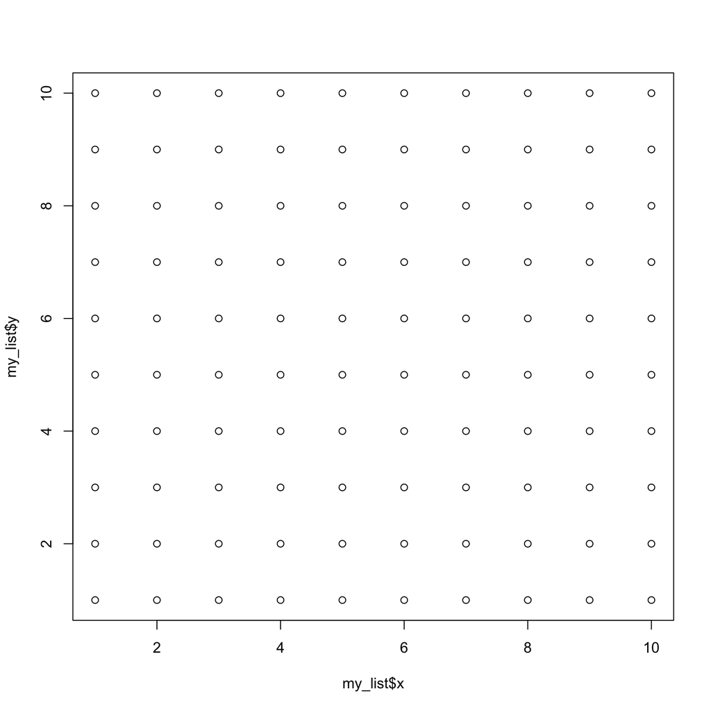

```r
my_list = list(x = rep(1:10,10),
               y = c(rep(1,10), rep(2,10), rep(3,10), rep(4,10), rep(5,10), rep(6,10), rep(7,10), rep(8,10), rep(9,10), rep(10,10))) #Functions are better here.

#Let's build a custom funciton. It's not so scary. We tell R what to do with a vector.

my_grid = function(x, times = 10){
  out = vector(mode = "numeric", length = length(x)*times) #Using length() function here. Allows us to be flexible.
  for(i in 1:length(x)){ #Yes, we use for() loops. For every position in our vector object, we're going to use the function rep.
    write_value = rep(x[i], times)
    out[1:10 + ((i-1) * 10)] = write_value
  }
  out
}

my_list = list(x = rep(1:10, 10),
               y = my_grid(1:10))

plot(my_list)

#The most efficient choice is a unique class of R functions centered around apply(). Here, we use sapply() to iteratively repeat the input 10 times.

my_list = list(x = rep(1:10, 10),
               y = sapply(1:10, function(x){
                    rep(x, 10)
                  })
               )

plot(my_list)
```

Add text.

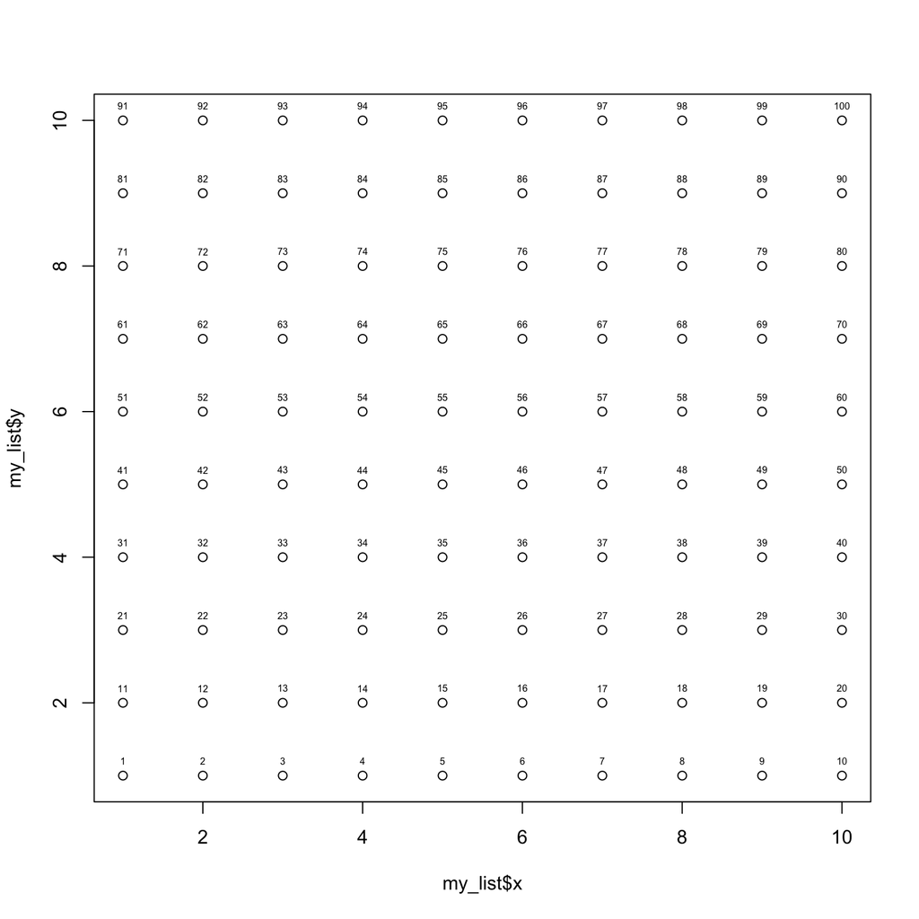

```r
plot(my_list)

text(x = my_list$x, #Using function text() to add text to plot. Note arguments
     y = my_list$y+0.2,
     labels = 1:100,
     cex = 0.5) #The cex argument changes the size of what is plotted. CEX stands for "character expansion".
```

Next jobs, vary inputs. “Point characters” are the symbols available in base R and there are 25 of them.

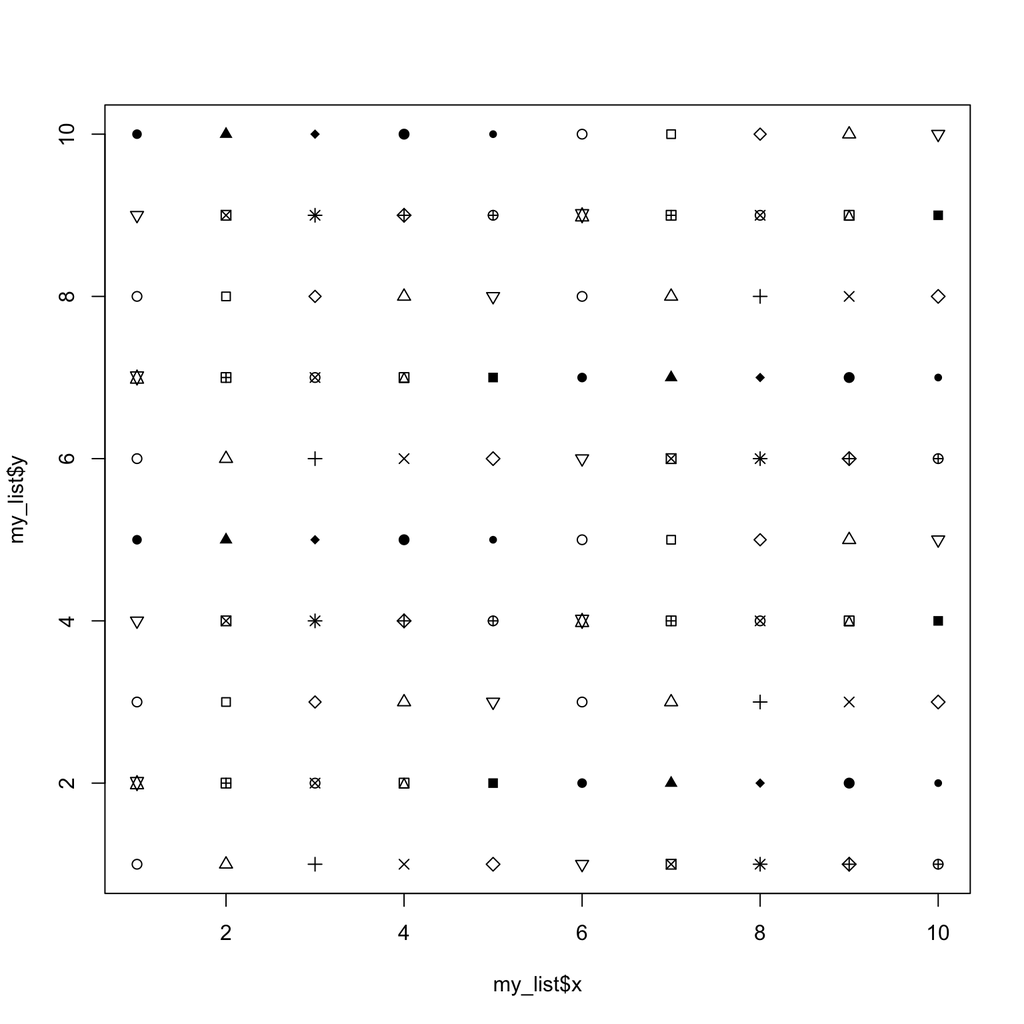

```r
plot(my_list, pch = 1:25)
```

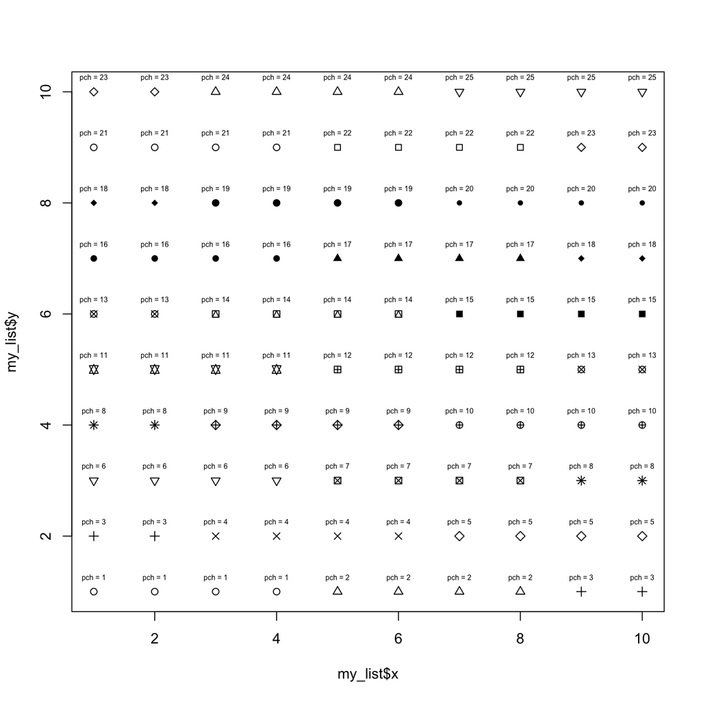

```r
#How do we make it so the characters show up as 4 of each in a row?

plot(my_list,
     pch = sapply(1:25, function(x){
       rep(x, 4)
     }))

#Can we add text to clarify? You bet!

text(x = my_list$x,
     y = my_list$y + 0.25,
     labels = paste0("pch = ",
              sapply(1:25, function(y){ #This is the code chunk we used to get our symbols into groups of 4.
                rep(y, 4)
              })),
     cex = 0.5)
```

The code chunk above is a bit clumsy. Let’s pull together something cleaner.

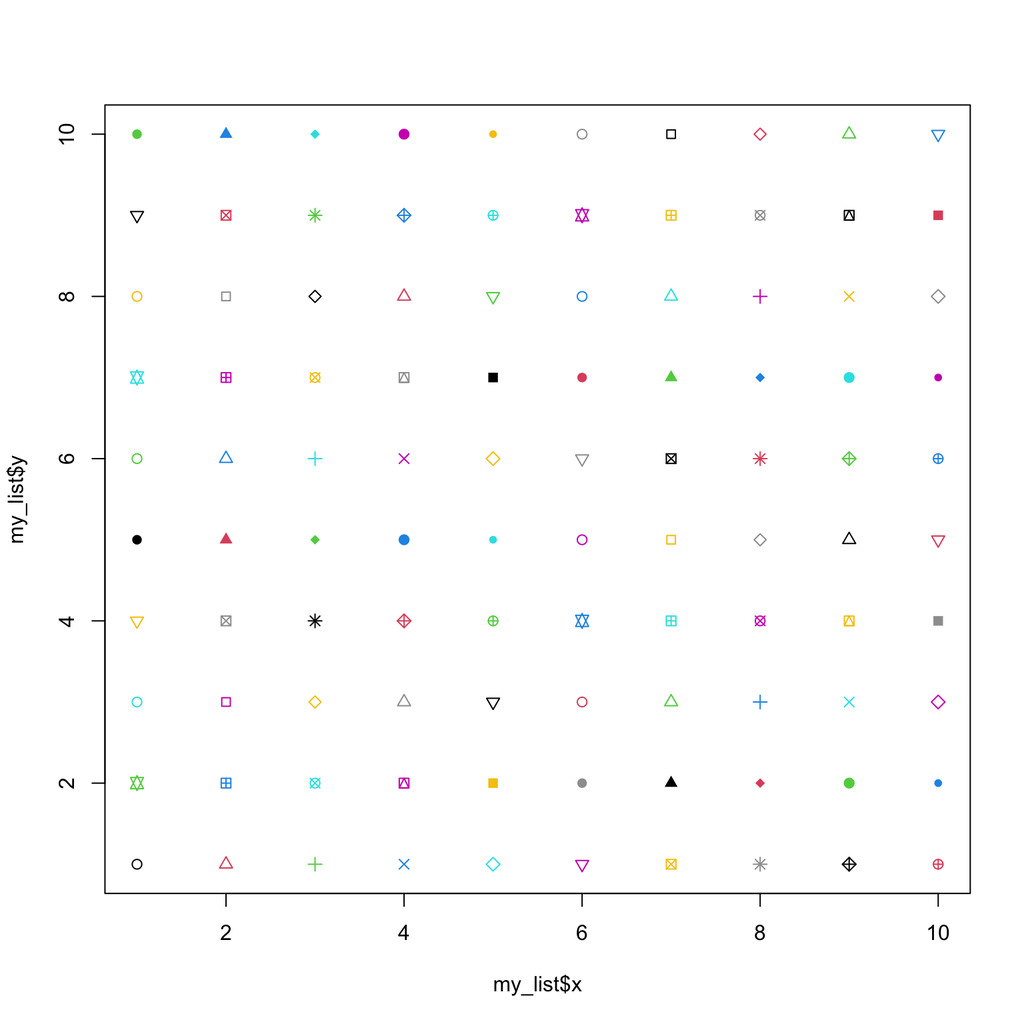

```r
plot(my_list,
     pch = 1:25,
     col = 1:8)
```